# NBA Salary Prediction

Marc Pastor

30th June 2020

## **NBA Salary Calculator**

In this project I am going to develop a model to predict the average salary of an NBA player, based on multiple variables and using tree methods. I will be using a regression tree as the base model, as well as bagging and random forests. The goal of this project is to create an “NBA Salary Calculator” through a Shiny App which is already in development.

[figure not shown]

## **The Data**

The data to train the model has been obtained from data.world. It consists of two datasets: the *players* dataset and the *salaries_1985to2018* table. Now we load these two datasets into two new variables:

```r
setwd("C:/Users/marct/OneDrive - Tecnocampus Mataro-Maresme/Documentos/CURSOS/PROJECTES/SALARIOS NBA/data")
players <- read.csv("./players.csv", sep = ",", dec = ".")
salaries <- read.csv("./salaries_1985to2018.csv", sep = ",", dec = ".")
```

### **Players dataset**

```r
str(players)
```

```
## 'data.frame':    4685 obs. of  24 variables:
##  $ X_id       : chr  "abdelal01" "abdulza01" "abdulka01" "abdulma02" ...
##  $ birthDate  : chr  "June 24, 1968" "April 7, 1946" "April 16, 1947" "March 9, 1969" ...
##  $ birthPlace : chr  "Cairo, Egypt" "Brooklyn, New York" "New York, New York" "Gulfport, Mississippi" ...
##  $ career_AST : num  0.3 1.2 3.6 3.5 1.1 2.5 1.2 1 0.7 0.5 ...
##  $ career_FG. : chr  "50.2" "42.8" "55.9" "44.2" ...
##  $ career_FG3.: chr  "0.0" "" "5.6" "35.4" ...
##  $ career_FT. : chr  "70.1" "72.8" "72.1" "90.5" ...
##  $ career_G   : int  256 505 1560 586 236 830 319 1 56 174 ...
##  $ career_PER : chr  "13.0" "15.1" "24.6" "15.4" ...
##  $ career_PTS : num  5.7 9 24.6 14.6 7.8 18.1 5.6 0 9.5 5.3 ...
##  $ career_TRB : chr  "3.3" "8.0" "11.2" "1.9" ...
##  $ career_WS  : chr  "4.8" "17.5" "273.4" "25.2" ...
##  $ career_eFG.: chr  "50.2" "" "55.9" "47.2" ...
##  $ college    : chr  "Duke University" "Iowa State University" "University of California, Los Angeles" "Louisiana State University" ...
##  $ draft_pick : chr  "25th overall" "5th overall" "1st overall" "3rd overall" ...
##  $ draft_round: chr  "1st round" "1st round" "1st round" "1st round" ...
##  $ draft_team : chr  "Portland Trail Blazers" "Cincinnati Royals" "Milwaukee Bucks" "Denver Nuggets" ...
##  $ draft_year : chr  "1990" "1968" "1969" "1990" ...
##  $ height     : chr  "6-10" "6-9" "7-2" "6-1" ...
##  $ highSchool : chr  "Bloomfield in Bloomfield, New Jersey" "John Jay in Brooklyn, New York" "Power Memorial in New York, New York" "Gulfport in Gulfport, Mississippi" ...
##  $ name       : chr  "Alaa Abdelnaby" "Zaid Abdul-Aziz" "Kareem Abdul-Jabbar" "Mahmoud Abdul-Rauf" ...
##  $ position   : chr  "Power Forward" "Power Forward and Center" "Center" "Point Guard" ...
##  $ shoots     : chr  "Right" "Right" "Right" "Right" ...
##  $ weight     : chr  "240lb" "235lb" "225lb" "162lb" ...
```

### **Salaries dataset**

This dataset contains the 7 following variables:

```r
str(salaries)
```

```
## 'data.frame':    14163 obs. of  7 variables:
##  $ league      : chr  "NBA" "NBA" "NBA" "NBA" ...
##  $ player_id   : chr  "abdelal01" "abdelal01" "abdelal01" "abdelal01" ...
##  $ salary      : int  395000 494000 500000 805000 650000 1530000 2030000 2000000 3000000 1660000 ...
##  $ season      : chr  "1990-91" "1991-92" "1992-93" "1993-94" ...
##  $ season_end  : int  1991 1992 1993 1994 1995 1985 1986 1988 1989 1991 ...
##  $ season_start: int  1990 1991 1992 1993 1994 1984 1985 1987 1988 1990 ...
##  $ team        : chr  "Portland Trail Blazers" "Portland Trail Blazers" "Boston Celtics" "Boston Celtics" ...
```

## **Data Wrangling**

First of all I load three packages that will come in handy during the cleaning process.

```r
library(tidyverse)
library(stringr)
library(lubridate)
```

```r
players$birthDate <- mdy(players$birthDate)
players$birthyear <- year(players$birthDate)
players$birthmonth <- month(players$birthDate)
players$birthday <- day(players$birthDate)
players$birthweekday <- wday(players$birthDate, label = F)
```

Since I am Spanish, I change the units system, for the weight and height variables (from lbs to kgs, and from inches to centimeters, respectively).

```r
players$height_ft <- as.numeric(sapply(str_split(players$height, pattern = "-"), "[[", 1))
players$height_inches <- as.numeric(sapply(str_split(players$height, pattern = "-"), "[[", 2))
players$height_cm <- 30.48 * players$height_ft + 2.54 * players$height_inches
players$weight <- as.numeric(sapply(str_split(players$weight, pattern = "lb"), "[[", 1))
players$weight_kgs <- players$weight * 0.453592
```

Since the data in the birthPlace variable contains data in the following format: “San Francisco, California” (two components), or “Eslovenia” (one component), I use a for loop to separate the two words (in case of having to components) or repeting the first word (in case of having one word). This allows me to standarize the format and to create two new variables (birthPlace_city and birthPlace_state_country), which could be useful.

```r
prueba <- str_split(players$birthPlace, pattern = ", ")
for(i in seq_along(prueba)){
        if (length(prueba[[i]]) == 1){
                prueba[[i]][2] <- prueba[[i]][1]
        } else{

        }
}

players$birthPlace_city <- sapply(prueba, "[[", 1)
players$birthPlace_state_country <- sapply(prueba, "[[", 2)
```

Then I create a country column with the help of the countrycode package, which includes the official name in English of all countries in the world. For that, I initialize a new variable in the players dataset (called birthPlace_country), setting it to 0. Then I use a for loop which extracts the state name (from the variable birthPlace_state_country) and if the ith observation of this variable in the dataset is also in the state.name vector (a vector containing all the US states names), it changes that value for “United States”, because I am more interested in the country rather than the state. This way, any observation belonging to any state from the USA, will be substituted with the “United States” (country name that I was interested on). If the ith observation of the birthPlace_state_country is not a US state (it is the name of another country), then it will remain the same.

```r
library(datasets)
library(countrycode)
players$birthPlace_country <- 0

for(i in seq_along(players$birthPlace_state_country)){
        if(players$birthPlace_state_country[i] %in% state.name){
                players$birthPlace_country[i] <- "United States"
        } else{
                players$birthPlace_country[i] <- players$birthPlace_state_country[i]
        }
}
```

Now I look up those country names that have spell mistakes. For that, I create a vector containing all the country names in the world, using the countrycode package and the function %notin%, that will come in handy when filtering the results. Then I check all the country names that are misspelled (line 100), by checking the names in the country_names vector. Then I substitute the wrong country names with the correct name. Finally I check again all the country_names, using the same command, and the only one that is detected as misspelled is “Czech Republic”, because in the country_names vector it is written as Czechoslovakia (nowadays extinct)

```r
country_names <- levels(as.factor(countryname_dict$country.name.en)) # vector containing all country names
'%notin%' <- Negate('%in%') # we create this function in order to filter easily
distinct(players[players$birthPlace_country != "" & players$birthPlace_country %notin% country_names , c(33,34)])
```

```
##        birthPlace_city         birthPlace_state_country
## 1               Skopje                    FYR Macedonia
## 2           Washington             District of Columbia
## 3            St. Croix                 U.S. VirgIslands
## 4             Capljina           Bosnia and Herzegovina
## 5           Lubumbashi Democratic Republic of the Congo
## 6               Mostar           Bosnia and Herzegovina
## 7             Castries                      Saint Lucia
## 8  Trinidad and Tobago              Trinidad and Tobago
## 9           St. Thomas                 U.S. VirgIslands
## 10            Sarajevo           Bosnia and Herzegovina
## 11            Kinshasa Democratic Republic of the Congo
## 12             Canouan Saint Vincent and the Grenadines
## 13               Ahvaz         Islamic Republic of Iran
## 14            Trinidad              Trinidad and Tobago
## 15         Brazzaville            Republic of the Congo
## 16               Tuzla           Bosnia and Herzegovina
## 17               Doboj           Bosnia and Herzegovina
## 18               Bihac           Bosnia and Herzegovina
## 19               Ohrid                    FYR Macedonia
## 20            Trebinje           Bosnia and Herzegovina
## 21              Prague                   Czech Republic
## 22               Seoul                Republic of Korea
## 23       Dar es Salaam      United Republic of Tanzania
## 24   Bosanska Gradiska           Bosnia and Herzegovina
## 25             Ostrava                   Czech Republic
## 26           Pardubice                   Czech Republic
## 27                Zlin                   Czech Republic
```

```r
players$birthPlace_country <- gsub("FYR Macedonia", "North Macedonia", players$birthPlace_country)
players$birthPlace_country <- gsub("District of Columbia", "United States", players$birthPlace_country)
players$birthPlace_country <- gsub("U.S. VirgIslands", "Congo - Brazzaville", players$birthPlace_country)
players$birthPlace_country <- gsub("Bosnia and Herzegovina", "Bosnia & Herzegovina", players$birthPlace_country)
players$birthPlace_country <- gsub("Democratic Republic of the Congo", "Congo - Brazzaville", players$birthPlace_country)
players$birthPlace_country <- gsub("Saint Lucia", "St. Lucia", players$birthPlace_country)
players$birthPlace_country <- gsub("Trinidad and Tobago", "Trinidad & Tobago", players$birthPlace_country)
players$birthPlace_country <- gsub("Saint Vincent and the Grenadines", "St. Vincent & Grenadines", players$birthPlace_country)
players$birthPlace_country <- gsub("Islamic Republic of Iran", "Iran", players$birthPlace_country)
players$birthPlace_country <- gsub("Republic of the Congo", "Congo - Brazzaville", players$birthPlace_country)
players$birthPlace_country <- gsub("Republic of Korea", "South Korea", players$birthPlace_country)
players$birthPlace_country <- gsub("United Republic of Tanzania", "Tanzania", players$birthPlace_country)

distinct(players[players$birthPlace_country != "" & players$birthPlace_country %notin% country_names , c(33,34)])
```

```
##   birthPlace_city birthPlace_state_country
## 1          Prague           Czech Republic
## 2         Ostrava           Czech Republic
## 3       Pardubice           Czech Republic
## 4            Zlin           Czech Republic
```

Now I change the values in the draft_pick and draft_round variables because they are inconsistent, and I will try to convert them to an homogeneous format. First we observe the different levels of the variable with the following code:

```r
players$draft_pick %>% as.factor() %>% levels()
```

```
##   [1] ""                          "100th overall"
##   [3] "101st overall"             "102nd overall"
##   [5] "103rd overall"             "104th overall"
##   [7] "106th overall"             "107th overall"
##   [9] "108th overall"             "109th overall"
##  [11] "10th overall"              "110th overall"
##  [13] "111th overall"             "112th overall"
##  [15] "113th overall"             "115th overall"
##  [17] "116th overall"             "117th overall"
##  [19] "118th overall"             "119th overall"
##  [21] "11th overall"              "120th overall"
##  [23] "121st overall"             "122nd overall"
##  [25] "123rd overall"             "124th overall"
##  [27] "125th overall"             "126th overall"
##  [29] "127th overall"             "128th overall"
```

[output cut: 83 more lines]

We can see that the final levels (“and Baltimore Bullets”, “and Boston Celtics”, etc) have a similar format (all of them contain the expression “and”). We use this fact in the gsub function, in order to convert those values to a homogeneous format (“ith overall”). Now we use the same method to substitute those observations containing “rd”, “nd”, “st”, with “th”, in order to have homogeneous data.

```r
players[grepl("and", players$draft_pick), "draft_pick"] <- "0th overall"
players[players$draft_pick == "", "draft_pick"] <- "0th overall"
players$draft_pick <- str_replace_all(players$draft_pick, "st|nd|rd", "th")
```

Now I filter those rows that for the same variable (draft_pick), are not in the “ith overall” format, and since they don’t show any information of the draft_pick, I substitute the value with “Oth overall”, which I will filter out later. Finally, when all observations of the variable are in a homogeneous format, I delete the " overall" part of each observation, and then the “th” and extract only the number.

```r
players[!grepl('th', players$draft_pick), "draft_pick"]
```

```
##  [1] "1953 NBA Draft" "1949 BAA Draft" "1949 BAA Draft" "1950 NBA Draft"
##  [5] "1949 BAA Draft" "1950 NBA Draft" "1949 BAA Draft" "1950 NBA Draft"
##  [9] "1949 BAA Draft" "1950 NBA Draft" "1950 NBA Draft" "1950 NBA Draft"
## [13] "1952 NBA Draft" "1950 NBA Draft" "1949 BAA Draft" "1950 NBA Draft"
## [17] "1952 NBA Draft" "1950 NBA Draft" "1950 NBA Draft" "1949 BAA Draft"
## [21] "1950 NBA Draft" "1949 BAA Draft" "1949 BAA Draft" "1949 BAA Draft"
## [25] "1950 NBA Draft" "1949 BAA Draft" "1950 NBA Draft" "1953 NBA Draft"
## [29] "1953 NBA Draft" "1952 NBA Draft" "1953 NBA Draft" "1950 NBA Draft"
## [33] "1949 BAA Draft" "1950 NBA Draft" "1949 BAA Draft" "1949 BAA Draft"
## [37] "1950 NBA Draft" "1950 NBA Draft" "1950 NBA Draft" "1950 NBA Draft"
## [41] "1949 BAA Draft" "1950 NBA Draft" "1949 BAA Draft" "1949 BAA Draft"
## [45] "1950 NBA Draft" "1950 NBA Draft" "1949 BAA Draft" "1950 NBA Draft"
## [49] "1949 BAA Draft" "1950 NBA Draft" "1949 BAA Draft" "1950 NBA Draft"
## [53] "1949 BAA Draft" "1950 NBA Draft" "1949 BAA Draft" "1953 NBA Draft"
## [57] "1950 NBA Draft" "1949 BAA Draft" "1950 NBA Draft" "1950 NBA Draft"
## [61] "1956 NBA Draft" "1953 NBA Draft" "1949 BAA Draft"
```

```r
players[!grepl('th', players$draft_pick), "draft_pick"] <- "0th overall"
players$draft_pick <- gsub(" overall", "", players$draft_pick)
players$draft_pick <- gsub("th", "", players$draft_pick)
```

Now I check if all the levels are homogeneous:

```r
players$draft_pick %>% as.factor() %>% levels()
```

```
##   [1] "0"   "1"   "10"  "100" "101" "102" "103" "104" "106" "107" "108" "109"
##  [13] "11"  "110" "111" "112" "113" "115" "116" "117" "118" "119" "12"  "120"
##  [25] "121" "122" "123" "124" "125" "126" "127" "128" "129" "13"  "130" "131"
##  [37] "132" "133" "134" "135" "136" "138" "139" "14"  "140" "141" "142" "144"
##  [49] "145" "146" "147" "148" "149" "15"  "150" "151" "152" "153" "154" "155"
##  [61] "156" "157" "158" "159" "16"  "160" "162" "163" "165" "166" "167" "168"
##  [73] "169" "17"  "175" "178" "18"  "180" "182" "185" "187" "189" "19"  "190"
##  [85] "197" "198" "2"   "20"  "202" "204" "205" "207" "21"  "211" "214" "215"
##  [97] "22"  "221" "224" "227" "23"  "24"  "25"  "26"  "27"  "28"  "29"  "3"
## [109] "30"  "31"  "32"  "33"  "34"  "35"  "36"  "37"  "38"  "39"  "4"   "40"
## [121] "41"  "42"  "43"  "44"  "45"  "46"  "47"  "48"  "49"  "5"   "50"  "51"
## [133] "52"  "53"  "54"  "55"  "56"  "57"  "58"  "59"  "6"   "60"  "61"  "62"
## [145] "63"  "64"  "65"  "66"  "67"  "68"  "69"  "7"   "70"  "71"  "72"  "73"
## [157] "74"  "75"  "76"  "77"  "78"  "79"  "8"   "80"  "81"  "82"  "83"  "84"
## [169] "85"  "86"  "87"  "88"  "89"  "9"   "90"  "91"  "92"  "93"  "94"  "95"
## [181] "96"  "97"  "98"  "99"
```

Now I do the same with the draft_round variable, but now using a for loop:

```r
players$draft_round <- str_replace_all(players$draft_round, "st|nd|rd", "th")
players[!grepl('th', players$draft_round), "draft_round"] <- "0th overall"
players$draft_round <- as.factor(players$draft_round)
players$draft_round %>% as.factor() %>% levels() # we use this in order to see which are the patterns to substitute
```

```
##  [1] "0th overall"
##  [2] "10th roun"
##  [3] "10th routh"
##  [4] "11th routh"
##  [5] "12th routh"
##  [6] "13th routh"
##  [7] "14th routh"
##  [8] "15th routh"
##  [9] "16th routh"
## [10] "17th routh"
## [11] "19th routh"
## [12] "1th overall in the 1971 Supplemental Hathship Draf"
## [13] "1th routh"
## [14] "2th overall in the 1971 Supplemental Hathship Draf"
## [15] "2th roun"
```

[output cut: 16 more lines]

```r
levels_draftround <- levels(as.factor(players$draft_round))
for(i in seq_along(levels_draftround)){
        patterns <- c(" overall", " routh", " in the 1971 Supplemental Hathship Draf", " roun")
        for(j in seq_along(patterns)){
                if(str_detect(levels_draftround[i], patterns[j] ) == TRUE){
                        levels_draftround[i] <- gsub(patterns[j], "", levels_draftround[i])
                } else {

                }
        }

}
levels_draftround <- gsub("th", "", levels_draftround)
levels(players$draft_round) <- levels_draftround
```

Now we check the draft team variable, but we will solve the problem of NA’s and empty values later

```r
players$draft_team %>% as.factor() %>% levels()
```

```
##  [1] ""                                  "Atlanta Hawks"
##  [3] "Baltimore Bullets"                 "Boston Celtics"
##  [5] "Brooklyn Nets"                     "Buffalo Braves"
##  [7] "Capital Bullets"                   "Charlotte Bobcats"
##  [9] "Charlotte Hornets"                 "Chicago Bulls"
## [11] "Chicago Packers"                   "Chicago Stags"
## [13] "Chicago Zephyrs"                   "Cincinnati Royals"
## [15] "Cleveland Cavaliers"               "Dallas Mavericks"
## [17] "Denver Nuggets"                    "Detroit Pistons"
## [19] "Fort Wayne Pistons"                "Golden State Warriors"
## [21] "Houston Rockets"                   "Indiana Pacers"
## [23] "Indianapolis Jets"                 "Indianapolis Olympians"
## [25] "Kansas City-Omaha Kings"           "Kansas City Kings"
## [27] "Los Angeles Clippers"              "Los Angeles Lakers"
## [29] "Memphis Grizzlies"                 "Miami Heat"
```

[output cut: 18 more lines]

Now I delete the useless variables in the salaries dataset, and rearrange the columns.

```r
salaries$league <- NULL
salaries$season <- NULL
salaries <- salaries[, c(1,4,3,2,5)]
head(salaries)
```

```
##   player_id season_start season_end  salary                   team
## 1 abdelal01         1990       1991  395000 Portland Trail Blazers
## 2 abdelal01         1991       1992  494000 Portland Trail Blazers
## 3 abdelal01         1992       1993  500000         Boston Celtics
## 4 abdelal01         1993       1994  805000         Boston Celtics
## 5 abdelal01         1994       1995  650000       Sacramento Kings
## 6 abdulka01         1984       1985 1530000     Los Angeles Lakers
```

```r
library(modeest)
```

Then I create dummy variables for each team, with the value 1 if the player played in that team during a year, in order to know how many years did the player play for each team. Then I change the name of the dummy variables with the for loop.

```r
library(fastDummies)
levels(as.factor(salaries$team))
```

```
##  [1] ""                                  "Atlanta Hawks"
##  [3] "Boston Celtics"                    "Brooklyn Nets"
##  [5] "Charlotte Bobcats"                 "Charlotte Hornets"
##  [7] "Chicago Bulls"                     "Cleveland Cavaliers"
##  [9] "Dallas Mavericks"                  "Denver Nuggets"
## [11] "Detroit Pistons"                   "Golden State Warriors"
## [13] "Houston Rockets"                   "Indiana Pacers"
## [15] "Kansas City Kings"                 "Los Angeles Clippers"
## [17] "Los Angeles Lakers"                "Memphis Grizzlies"
## [19] "Miami Heat"                        "Milwaukee Bucks"
## [21] "Minnesota Timberwolves"            "New Jersey Nets"
## [23] "New Orleans Hornets"               "New Orleans Pelicans"
## [25] "New Orleans/Oklahoma City Hornets" "New York Knicks"
## [27] "Oklahoma City Thunder"             "Orlando Magic"
## [29] "Philadelphia 76ers"                "Phoenix Suns"
## [31] "Portland Trail Blazers"            "Sacramento Kings"
## [33] "San Antonio Spurs"                 "Seattle SuperSonics"
## [35] "Toronto Raptors"                   "Utah Jazz"
## [37] "Vancouver Grizzlies"               "Washington Bullets"
## [39] "Washington Wizards"
```

```r
salaries <- dummy_cols(salaries, select_columns = "team")[,-6] # I remove the 6th column because it didn't represent any team
salaries$team <- NULL
# Now we cange the names of the dummy variables
for(i in 5:ncol(salaries)){
        colnames(salaries)[i] <- gsub("team", "yearsplayed", colnames(salaries)[i])
        colnames(salaries)[i] <- gsub(" ", "", colnames(salaries)[i])
}
head(salaries)
```

```
##   player_id season_start season_end  salary yearsplayed_AtlantaHawks
## 1 abdelal01         1990       1991  395000                        0
## 2 abdelal01         1991       1992  494000                        0
## 3 abdelal01         1992       1993  500000                        0
## 4 abdelal01         1993       1994  805000                        0
## 5 abdelal01         1994       1995  650000                        0
## 6 abdulka01         1984       1985 1530000                        0
##   yearsplayed_BostonCeltics yearsplayed_BrooklynNets
## 1                         0                        0
## 2                         0                        0
## 3                         1                        0
## 4                         1                        0
## 5                         0                        0
## 6                         0                        0
##   yearsplayed_CharlotteBobcats yearsplayed_CharlotteHornets
```

[output cut: 125 more lines]

Now I separate the salaries dataframe into two dataframes, to ease the process of summarizing. This gives me the carreer average salary for each player, as well as the number of years he played for each team.

```r
salaries_1 <- salaries[, c(1, 4)]
salaries_2 <- salaries[, c(1, 5:ncol(salaries))]
salaries_1 <- salaries_1 %>% group_by(player_id) %>% summarize(carreer_avg_salary = mean(salary)) %>% as.data.frame()
salaries_2 <- salaries_2 %>% group_by(player_id) %>% summarise_all("sum") %>% as.data.frame()
salaries <- inner_join(salaries_1, salaries_2, by = "player_id")
head(salaries)
```

```
##   player_id carreer_avg_salary yearsplayed_AtlantaHawks
## 1 abdelal01             568800                        0
## 2 abdulka01            2140000                        0
## 3 abdulma02            2205500                        0
## 4 abdulta01            3798280                        0
## 5 abdursh01            8715091                        3
## 6 abrinal01            5859882                        0
##   yearsplayed_BostonCeltics yearsplayed_BrooklynNets
## 1                         2                        0
## 2                         0                        0
## 3                         0                        0
## 4                         0                        0
## 5                         0                        0
## 6                         0                        0
##   yearsplayed_CharlotteBobcats yearsplayed_CharlotteHornets
```

[output cut: 125 more lines]

Finally I use the same name for the primary key column (player_id) and merge the two datasets (players and salaries) into de nba_dataset

```r
colnames(players)[1] <- "player_id"
nba_dataset <- inner_join(players, salaries, by = "player_id")
head(nba_dataset)
```

```
##   player_id  birthDate               birthPlace career_AST career_FG.
## 1 abdelal01 1968-06-24             Cairo, Egypt        0.3       50.2
## 2 abdulka01 1947-04-16       New York, New York        3.6       55.9
## 3 abdulma02 1969-03-09    Gulfport, Mississippi        3.5       44.2
## 4 abdulta01 1974-11-03   Maisons Alfort, France        1.1       41.7
## 5 abdursh01 1976-12-11        Marietta, Georgia        2.5       47.2
## 6 abrinal01 1993-08-01 Palma de Mallorca, Spain        0.5       38.7
##   career_FG3. career_FT. career_G career_PER career_PTS career_TRB career_WS
## 1         0.0       70.1      256       13.0        5.7        3.3       4.8
## 2         5.6       72.1     1560       24.6       24.6       11.2     273.4
## 3        35.4       90.5      586       15.4       14.6        1.9      25.2
## 4        23.7       70.3      236       11.4        7.8        3.3       3.5
## 5        29.7       81.0      830       19.0       18.1        7.5      71.2
## 6        36.8       88.0      174        8.8        5.3        1.4       5.0
##   career_eFG.                                           college draft_pick
```

[output cut: 174 more lines]

Then I delete the unnecessary columns and rearrange the columns of the new dataset

```r
nba_dataset$birthPlace <- NULL
nba_dataset$height <- NULL
nba_dataset$weight <- NULL
nba_dataset$height_ft <- NULL
nba_dataset$height_inches <- NULL
nba_dataset$birthPlace_city <- NULL
nba_dataset$birthPlace_state_country <- NULL
nba_dataset$highSchool <- NULL


nba_dataset <- nba_dataset[, c(1, 18, 21, 22, 23, 24, 25, 26, 27, 13, 17,
                               14, 15, 16, 19, 20, 28, 3, 4, 5, 6, 7,
                               8, 9, 10, 11, 12, 29:ncol(nba_dataset))]
head(nba_dataset)
```

```
##   player_id                name birthyear birthmonth birthday birthweekday
## 1 abdelal01      Alaa Abdelnaby      1968          6       24            2
## 2 abdulka01 Kareem Abdul-Jabbar      1947          4       16            4
## 3 abdulma02  Mahmoud Abdul-Rauf      1969          3        9            1
## 4 abdulta01   Tariq Abdul-Wahad      1974         11        3            1
## 5 abdursh01 Shareef Abdur-Rahim      1976         12       11            7
## 6 abrinal01        Alex Abrines      1993          8        1            1
##   height_cm weight_kgs birthPlace_country
## 1    208.28   108.8621              Egypt
## 2    218.44   102.0582      United States
## 3    185.42    73.4819      United States
## 4    198.12   101.1510             France
## 5    205.74   102.0582      United States
## 6    198.12    90.7184              Spain
##                                             college draft_year draft_pick
```

[output cut: 160 more lines]

Now we delete the missing and strange values, and we also convert the columns to their most adequate data type.

```r
nba_dataset[, c(1, 2, 9, 10, 14, 15, 16)] <-  data.frame(lapply(nba_dataset[, c(1, 2, 9, 10, 14, 15, 16)], as.factor)) # Categorical Data
lapply(nba_dataset[, c(1,2,9,10,14,15,16)], levels) # we observe the levels in order to spot strange values
```

```
## $player_id
##    [1] "abdelal01" "abdulka01" "abdulma02" "abdulta01" "abdursh01" "abrinal01"
##    [7] "ackeral01" "acresma01" "acyqu01"   "adamsal01" "adamsha01" "adamsjo01"
##   [13] "adamsmi01" "adamsst01" "addisra01" "adebaba01" "adrieje01" "afflaar01"
##   [19] "agerma01"  "aguirma01" "ahearbl01" "aingeda01" "ajincal01" "akognjo01"
##   [25] "alabiso01" "alarima01" "aldemfu01" "aldrico01" "aldrila01" "alexacl01"
##   [31] "alexaco01" "alexaco02" "alexaga01" "alexajo01" "alexavi01" "alforst01"
##   [37] "allenja01" "allenje01" "allenla01" "allenma01" "allenra02" "allento01"
##   [43] "almonmo01" "alstode01" "alstora01" "amaecjo01" "amayaas01" "aminual01"
##   [49] "amundlo01" "anderal01" "anderch01" "anderda03" "anderde01" "anderer01"
##   [55] "andergr01" "anderja01" "anderju01" "anderke01" "anderky01" "anderni01"
##   [61] "anderri01" "anderro01" "anderry01" "andersh01" "anderwi01" "andrima01"
##   [67] "anigbik01" "anslemi01" "anstech01" "antetgi01" "antetth01" "anthoca01"
##   [73] "anthogr01" "anthojo01" "anticpe01" "anunoog01" "applike01" "araujra01"
##   [79] "archiro01" "arenagi01" "arizatr01" "armstbj01" "armstbr01" "armstda01"
```

[output cut: 2190 more lines]

```r
# Now we change those strange values with "Unknown" followed by the column name

nba_dataset[, c(1, 2, 9, 10, 14, 15, 16)] <-  data.frame(lapply(nba_dataset[, c(1, 2, 9, 10, 14, 15, 16)], as.character)) # we convert them to character again

nba_dataset[, -c(1, 2, 9, 10, 14, 15, 16)] <- data.frame(lapply(nba_dataset[, -c(1, 2, 9, 10, 14, 15, 16)], as.numeric)) # these are the numeric columns
for(j in c(1, 2, 9, 10, 14, 15, 16)){
        for(i in 1 : nrow(nba_dataset)){
                if(nba_dataset[i, j] == ""){
                        nba_dataset[i, j] <- paste("Unknown", colnames(nba_dataset)[j])
                }
        }
}
```

### **Dealing with NA’s (numeric data)**

First we check if there are NA’s in the data:

```r
head(nba_dataset[is.na(nba_dataset), ])
```

```
##      player_id name birthyear birthmonth birthday birthweekday height_cm
## NA        <NA> <NA>        NA         NA       NA           NA        NA
## NA.1      <NA> <NA>        NA         NA       NA           NA        NA
## NA.2      <NA> <NA>        NA         NA       NA           NA        NA
## NA.3      <NA> <NA>        NA         NA       NA           NA        NA
## NA.4      <NA> <NA>        NA         NA       NA           NA        NA
## NA.5      <NA> <NA>        NA         NA       NA           NA        NA
##      weight_kgs birthPlace_country college draft_year draft_pick draft_round
## NA           NA               <NA>    <NA>         NA         NA          NA
## NA.1         NA               <NA>    <NA>         NA         NA          NA
## NA.2         NA               <NA>    <NA>         NA         NA          NA
## NA.3         NA               <NA>    <NA>         NA         NA          NA
## NA.4         NA               <NA>    <NA>         NA         NA          NA
## NA.5         NA               <NA>    <NA>         NA         NA          NA
##      draft_team position shoots carreer_avg_salary career_AST career_FG.
## NA         <NA>     <NA>   <NA>                 NA         NA         NA
## NA.1       <NA>     <NA>   <NA>                 NA         NA         NA
## NA.2       <NA>     <NA>   <NA>                 NA         NA         NA
## NA.3       <NA>     <NA>   <NA>                 NA         NA         NA
## NA.4       <NA>     <NA>   <NA>                 NA         NA         NA
## NA.5       <NA>     <NA>   <NA>                 NA         NA         NA
##      career_FG3. career_FT. career_G career_PER career_PTS career_TRB career_WS
## NA            NA         NA       NA         NA         NA         NA        NA
## NA.1          NA         NA       NA         NA         NA         NA        NA
## NA.2          NA         NA       NA         NA         NA         NA        NA
## NA.3          NA         NA       NA         NA         NA         NA        NA
## NA.4          NA         NA       NA         NA         NA         NA        NA
## NA.5          NA         NA       NA         NA         NA         NA        NA
##      career_eFG. yearsplayed_AtlantaHawks yearsplayed_BostonCeltics
## NA            NA                       NA                        NA
## NA.1          NA                       NA                        NA
## NA.2          NA                       NA                        NA
## NA.3          NA                       NA                        NA
## NA.4          NA                       NA                        NA
## NA.5          NA                       NA                        NA
##      yearsplayed_BrooklynNets yearsplayed_CharlotteBobcats
## NA                         NA                           NA
## NA.1                       NA                           NA
## NA.2                       NA                           NA
## NA.3                       NA                           NA
```

[output cut: 106 more lines]

```
## NA.5                             NA                         NA
##      yearsplayed_UtahJazz yearsplayed_VancouverGrizzlies
## NA                     NA                             NA
## NA.1                   NA                             NA
## NA.2                   NA                             NA
## NA.3                   NA                             NA
## NA.4                   NA                             NA
## NA.5                   NA                             NA
##      yearsplayed_WashingtonBullets yearsplayed_WashingtonWizards
## NA                              NA                            NA
## NA.1                            NA                            NA
## NA.2                            NA                            NA
## NA.3                            NA                            NA
## NA.4                            NA                            NA
## NA.5                            NA                            NA
```

Now we substitute the NA’s with the median column value for the players of the same birthyear using two nested for loops. I choose the median and not the mean, because the median is less afected by outliers.

```r
for(j in 1:ncol(nba_dataset)){
        years <- vector()
        for(i in 1:nrow(nba_dataset)){
                if(is.numeric(nba_dataset[, j]) == TRUE){
                        if(is.na(nba_dataset[i, j]) == TRUE){
                                years[i] <- nba_dataset$birthyear[i]
                                nba_dataset[i, j] <- nba_dataset[complete.cases(nba_dataset) & nba_dataset$birthyear == years[i], j] %>% median()
                        }
                }
        }

}
```

Now we check that there are no NA’s.

```r
head(nba_dataset[is.na(nba_dataset), ])
```

```
##  [1] player_id
##  [2] name
##  [3] birthyear
##  [4] birthmonth
##  [5] birthday
##  [6] birthweekday
##  [7] height_cm
##  [8] weight_kgs
##  [9] birthPlace_country
## [10] college
## [11] draft_year
## [12] draft_pick
## [13] draft_round
## [14] draft_team
## [15] position
```

[output cut: 51 more lines]

I use the countrycode library to obtain the continent where each player was born, and I also delete some unnecessary columns

```r
library(countrycode)

nba_dataset$birthPlace_continent <- countrycode(sourcevar = nba_dataset[, "birthPlace_country"],
                                     origin = "country.name", destination = "continent")
nba_dataset <- nba_dataset[, -c(1, 2, 6, 9, 10)]
nba_dataset <- nba_dataset[, c(61, 1:60)]
nba_dataset <- nba_dataset[, -c(24:61)]
```

Finally we have cleaned our dataset, and we are ready to start analyzing and modelling.

```r
head(nba_dataset)
```

```
##   birthPlace_continent birthyear birthmonth birthday height_cm weight_kgs
## 1               Africa      1968          6       24    208.28   108.8621
## 2             Americas      1947          4       16    218.44   102.0582
## 3             Americas      1969          3        9    185.42    73.4819
## 4               Europe      1974         11        3    198.12   101.1510
## 5             Americas      1976         12       11    205.74   102.0582
## 6               Europe      1993          8        1    198.12    90.7184
##   draft_year draft_pick draft_round             draft_team
## 1       1990         25          11 Portland Trail Blazers
## 2       1969          1          11        Milwaukee Bucks
## 3       1990          3          11         Denver Nuggets
## 4       1997         11          11       Sacramento Kings
## 5       1996          3          11    Vancouver Grizzlies
## 6       2013         32          12  Oklahoma City Thunder
##                                     position shoots carreer_avg_salary
```

[output cut: 20 more lines]

## **Exploratory Data Analysis**

First I check the structure and summary of the nba_dataset, and then check the presence of missing values and NA’s.

```r
str(nba_dataset)
```

```
## 'data.frame':    2408 obs. of  23 variables:
##  $ birthPlace_continent: chr  "Africa" "Americas" "Americas" "Europe" ...
##  $ birthyear           : num  1968 1947 1969 1974 1976 ...
##  $ birthmonth          : num  6 4 3 11 12 8 1 11 10 7 ...
##  $ birthday            : num  24 16 9 3 11 1 21 15 6 19 ...
##  $ height_cm           : num  208 218 185 198 206 ...
##  $ weight_kgs          : num  108.9 102.1 73.5 101.2 102.1 ...
##  $ draft_year          : num  1990 1969 1990 1997 1996 ...
##  $ draft_pick          : num  25 1 3 11 3 32 60 40 37 4 ...
##  $ draft_round         : num  11 11 11 11 11 12 12 12 12 11 ...
##  $ draft_team          : chr  "Portland Trail Blazers" "Milwaukee Bucks" "Denver Nuggets" "Sacramento Kings" ...
##  $ position            : chr  "Power Forward" "Center" "Point Guard" "Shooting Guard" ...
##  $ shoots              : chr  "Right" "Right" "Right" "Right" ...
##  $ carreer_avg_salary  : num  568800 2140000 2205500 3798280 8715091 ...
##  $ career_AST          : num  0.3 3.6 3.5 1.1 2.5 0.5 0.5 0.5 0.6 4.1 ...
##  $ career_FG.          : num  50.2 55.9 44.2 41.7 47.2 38.7 37 50.6 44.4 49.8 ...
##  $ career_FG3.         : num  0 5.6 35.4 23.7 29.7 36.8 32 53.8 35 13.3 ...
##  $ career_FT.          : num  70.1 72.1 90.5 70.3 81 88 50 66.5 75.9 78.8 ...
##  $ career_G            : num  256 1560 586 236 830 174 30 375 337 988 ...
##  $ career_PER          : num  13 24.6 15.4 11.4 19 8.8 8.5 9 11.2 18.3 ...
##  $ career_PTS          : num  5.7 24.6 14.6 7.8 18.1 5.3 2.7 3.6 4.9 14.1 ...
##  $ career_TRB          : num  3.3 11.2 1.9 3.3 7.5 1.4 1 4.1 3.5 7 ...
##  $ career_WS           : num  4.8 273.4 25.2 3.5 71.2 ...
##  $ career_eFG.         : num  50.2 55.9 47.2 42.2 47.9 52.5 41.3 50.9 51.3 49.8 ...
```

```r
summary(nba_dataset)
```

```
##  birthPlace_continent   birthyear      birthmonth       birthday
##  Length:2408          Min.   :1947   Min.   : 1.00   Min.   : 1.00
##  Class :character     1st Qu.:1967   1st Qu.: 3.00   1st Qu.: 8.00
##  Mode  :character     Median :1977   Median : 6.00   Median :16.00
##                       Mean   :1977   Mean   : 6.44   Mean   :15.79
##                       3rd Qu.:1987   3rd Qu.: 9.00   3rd Qu.:23.00
##                       Max.   :1998   Max.   :12.00   Max.   :31.00
##    height_cm       weight_kgs       draft_year     draft_pick   draft_round
##  Min.   :160.0   Min.   : 60.33   Min.   :1969   Min.   :  0   Min.   : 1.000
##  1st Qu.:193.0   1st Qu.: 88.45   1st Qu.:1990   1st Qu.:  2   1st Qu.:11.000
##  Median :200.7   Median : 97.98   Median :1999   Median : 17   Median :11.000
##  Mean   :200.7   Mean   : 98.61   Mean   :1999   Mean   : 22   Mean   : 9.262
##  3rd Qu.:208.3   3rd Qu.:107.05   3rd Qu.:2008   3rd Qu.: 35   3rd Qu.:12.000
##  Max.   :231.1   Max.   :163.29   Max.   :2017   Max.   :221   Max.   :19.000
##   draft_team          position            shoots          carreer_avg_salary
##  Length:2408        Length:2408        Length:2408        Min.   :    2706
##  Class :character   Class :character   Class :character   1st Qu.:  349250
##  Mode  :character   Mode  :character   Mode  :character   Median :  931784
##                                                           Mean   : 1964587
##                                                           3rd Qu.: 2535453
##                                                           Max.   :16411903
##    career_AST       career_FG.      career_FG3.      career_FT.
##  Min.   : 0.000   Min.   :  0.00   Min.   :  0.0   Min.   :  0.00
##  1st Qu.: 0.500   1st Qu.: 40.50   1st Qu.: 18.8   1st Qu.: 66.10
##  Median : 1.100   Median : 43.95   Median : 29.9   Median : 73.80
##  Mean   : 1.551   Mean   : 43.58   Mean   : 25.8   Mean   : 71.52
##  3rd Qu.: 2.100   3rd Qu.: 47.90   3rd Qu.: 34.5   3rd Qu.: 79.10
##  Max.   :11.200   Max.   :100.00   Max.   :100.0   Max.   :100.00
##     career_G        career_PER       career_PTS       career_TRB
##  Min.   :   1.0   Min.   :-48.60   Min.   : 0.000   Min.   : 0.00
##  1st Qu.:  69.0   1st Qu.:  9.80   1st Qu.: 3.200   1st Qu.: 1.50
##  Median : 255.0   Median : 12.20   Median : 5.800   Median : 2.60
##  Mean   : 367.6   Mean   : 12.03   Mean   : 6.993   Mean   : 3.09
##  3rd Qu.: 612.0   3rd Qu.: 14.60   3rd Qu.: 9.500   3rd Qu.: 4.10
##  Max.   :1611.0   Max.   : 88.30   Max.   :30.100   Max.   :13.70
##    career_WS       career_eFG.
##  Min.   : -2.70   Min.   :  0.00
##  1st Qu.:  0.30   1st Qu.: 43.90
##  Median :  5.60   Median : 47.50
##  Mean   : 19.12   Mean   : 46.47
##  3rd Qu.: 26.00   3rd Qu.: 50.50
##  Max.   :273.40   Max.   :150.00
```

```r
head(nba_dataset[is.na(nba_dataset), ]) # there are no NA's
```

```
##  [1] birthPlace_continent birthyear            birthmonth
##  [4] birthday             height_cm            weight_kgs
##  [7] draft_year           draft_pick           draft_round
## [10] draft_team           position             shoots
## [13] carreer_avg_salary   career_AST           career_FG.
## [16] career_FG3.          career_FT.           career_G
## [19] career_PER           career_PTS           career_TRB
## [22] career_WS            career_eFG.
## <0 rows> (or 0-length row.names)
```

```r
head(nba_dataset[!complete.cases(nba_dataset), ]) # there are no missing values, since we have substituted them earlier
```

```
##  [1] birthPlace_continent birthyear            birthmonth
##  [4] birthday             height_cm            weight_kgs
##  [7] draft_year           draft_pick           draft_round
## [10] draft_team           position             shoots
## [13] carreer_avg_salary   career_AST           career_FG.
## [16] career_FG3.          career_FT.           career_G
## [19] career_PER           career_PTS           career_TRB
## [22] career_WS            career_eFG.
## <0 rows> (or 0-length row.names)
```

Now I check the variable that I want to predict (carreer_avg_salary), in order to detect trends and extract insights. The first histogram, corresponds to the log of carreer_avg_salary. It clearly shows us that the variable is pretty gaussian, because most of the players earn between exp(12.5) and exp(15) dollars, (268337 and 3269017$)

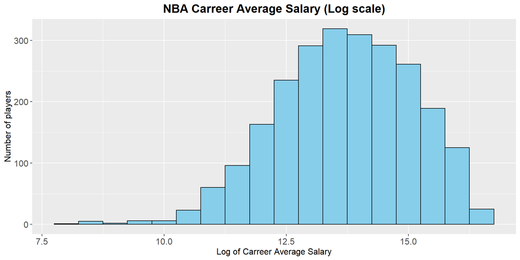

```r
ggplot(data = nba_dataset, aes(x = log(carreer_avg_salary))) +
        geom_histogram(binwidth = 0.5, color = "black", fill = "skyblue") +
        ggtitle("NBA Carreer Average Salary (Log scale)") +
        theme(plot.title = element_text(hjust = 0.5, size = 16, face = "bold"),
              axis.title = element_text(hjust = 0.5, size = 12),
              axis.text = element_text(size = 12)) +
        xlab("Log of Carreer Average Salary") + ylab("Number of players")
```

### **Categorical variables**

This other chart shows us the average salary of a player depending on its birth continent. All of the continents seem to have very similar values, being players from oceania the players that on average make more money. This is for sure because most of the players are American, and as the number of players increases, the average value decreases, while maybe there are fewer players from Oceania that on average have higher salaries. Again the majority of the players have salaries (log variable) between 12.5 and 15.

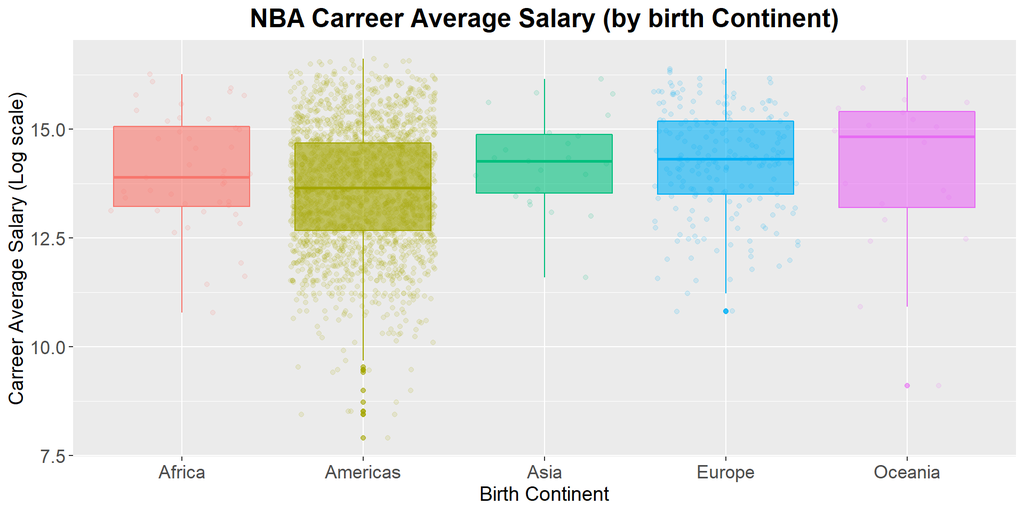

```r
ggplot(data = nba_dataset, aes(x = birthPlace_continent, y = log(carreer_avg_salary))) +
        geom_jitter(aes(col = birthPlace_continent), alpha = 0.13) +
        geom_boxplot(alpha = 0.6, aes(fill = birthPlace_continent, col = birthPlace_continent)) +
        ggtitle("NBA Carreer Average Salary (by birth Continent)") +
        theme(plot.title = element_text(hjust = 0.5, size = 18, face = "bold"),
              axis.title = element_text(hjust = 0.5, size = 14),
              axis.text = element_text(size = 13), legend.position = "none") +
        xlab("Birth Continent") + ylab("Carreer Average Salary (Log scale)")
```

There doesn’t seem to be any clear pattern in this chart, and again, most of the players lay between the 12.5 and 15 log values of salary.

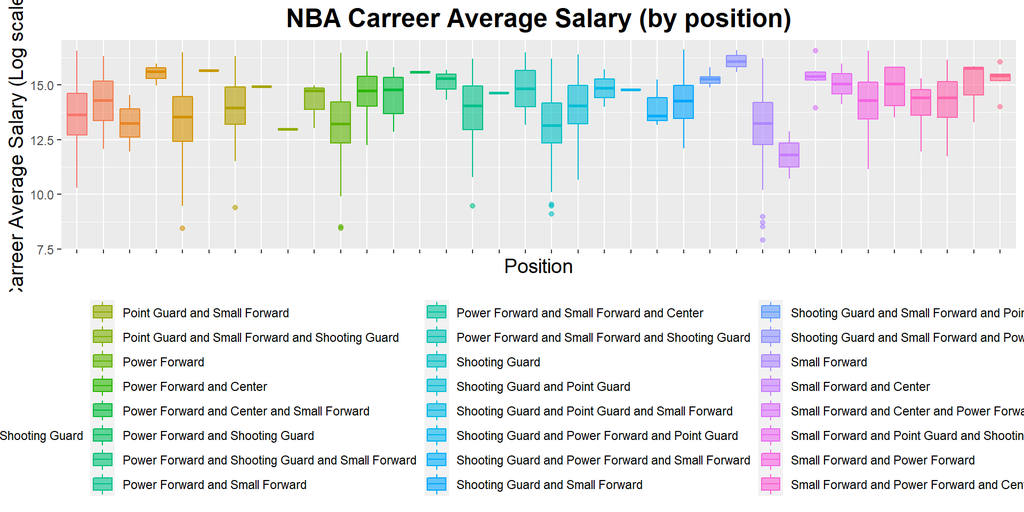

```r
ggplot(data = nba_dataset, aes(x = position, y = log(carreer_avg_salary))) +
        geom_boxplot(alpha = 0.6, aes(fill = position, col = position)) +
        ggtitle("NBA Carreer Average Salary (by position)") +
        theme(plot.title = element_text(hjust = 0.5, size = 18, face = "bold"),
              axis.title = element_text(hjust = 0.5, size = 14),
              axis.text.x = element_blank(),
              legend.position = "bottom",
              legend.title = element_blank()) +
        xlab("Position") + ylab("Carreer Average Salary (Log scale)")
```

Finally we check if the shooting hand affects the salary, and as we can see, it has little impact.

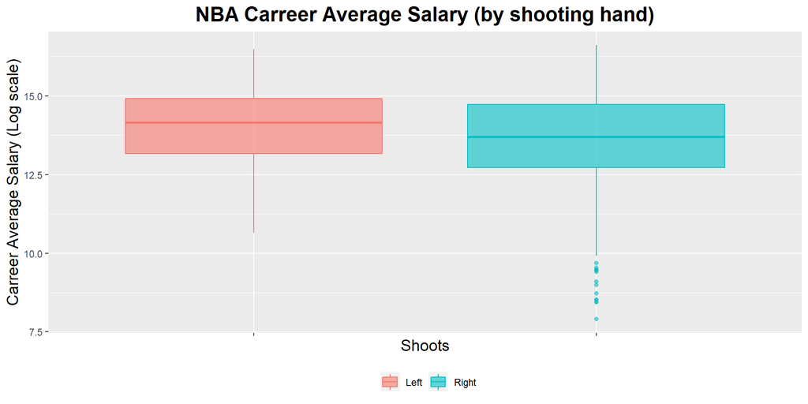

```r
ggplot(data = filter(nba_dataset, shoots != "Left Right"), aes(x = shoots, y = log(carreer_avg_salary))) +
        geom_boxplot(alpha = 0.6, aes(fill = shoots, col = shoots)) +
        ggtitle("NBA Carreer Average Salary (by shooting hand)") +
        theme(plot.title = element_text(hjust = 0.5, size = 18, face = "bold"),
              axis.title = element_text(hjust = 0.5, size = 14),
              axis.text.x = element_blank(),
              legend.position = "bottom",
              legend.title = element_blank()) +
        xlab("Shoots") + ylab("Carreer Average Salary (Log scale)")
```

### **Numeric variables**

Now we check for correlation between the numeric variables and carreer_avg_salary. As we can see, the most correlated variables are all related to basketball stats, such as the PTS, WS, TRB, etc. These stats summarise the performance of a player in the court. This is logic, since the salary of a player depends on his performance.

```r
library(corrr)
numeric_correlations <- nba_dataset[, -c(1, 10, 11, 12)] %>% correlate() %>% focus(carreer_avg_salary)
```

```
##
## Correlation method: 'pearson'
## Missing treated using: 'pairwise.complete.obs'
```

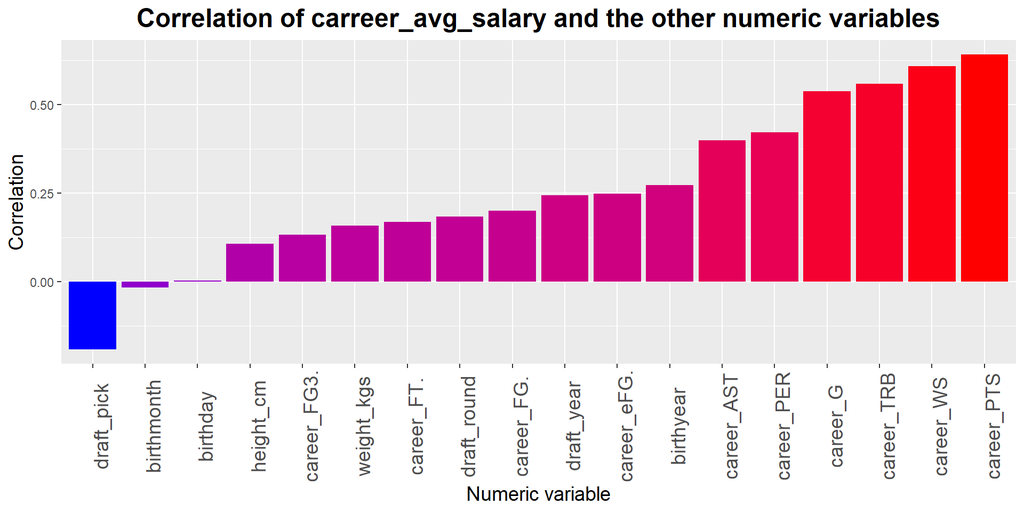

```r
ggplot(data = numeric_correlations, aes(x = reorder(rowname, carreer_avg_salary), y = carreer_avg_salary)) +
        geom_bar(aes(fill = carreer_avg_salary), stat = "identity") +
        scale_fill_gradient(low = "blue", high = "red") +
        ggtitle("Correlation of carreer_avg_salary and the other numeric variables") +
        theme(plot.title = element_text(hjust = 0.5, size = 18, face = "bold"),
              axis.title = element_text(hjust = 0.5, size = 14),
              axis.text.x = element_text(size = 14, angle = 90),
              legend.position = "none",
              legend.title = element_blank()) +
        xlab("Numeric variable") + ylab("Correlation")
```

## **Modeling**

In order to predict the carreer_avg_salary variable I try three different tree based methods: Regression Trees, Bagging and Random Forests.

### **Regression Tree**

I load the tree package, create a “salary” variable containing all the salaries from all players in the dataset. Then I create random training and testing partitions using a seed (in order to increase reproducibility), and train the model in the training partition.

```r
library(tree)
salary <- nba_dataset$carreer_avg_salary
set.seed(2)
train <- sample(1:nrow(nba_dataset), nrow(nba_dataset)/2)
nba_dataset.test <- nba_dataset[-train, ]
salary.test <- salary[-train]
tree.nba_dataset <- tree::tree(carreer_avg_salary ~., data = nba_dataset, subset = train)
```

Now I use cross validation to apply cost complexity pruning and the result tells me that the best tree is the unpruned one (aka the one I obtained in the previous code chunk)

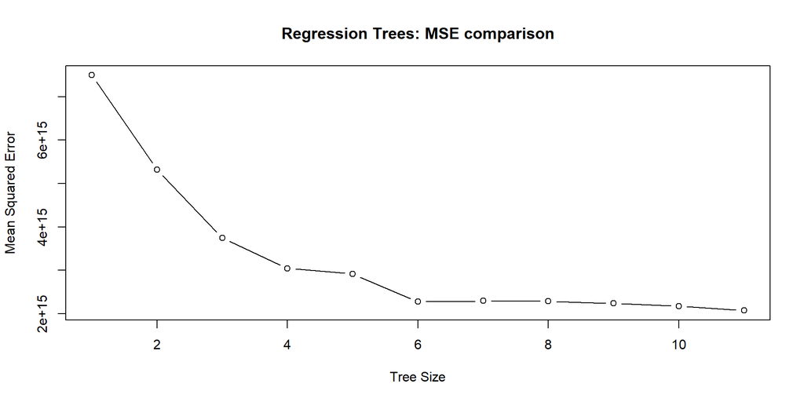

```r
cv.nba_dataset <- cv.tree(tree.nba_dataset)
plot(cv.nba_dataset$size, cv.nba_dataset$dev, type = "b", main = "Regression Trees: MSE comparison",
     xlab = "Tree Size", ylab = "Mean Squared Error")
```

The best tree is the unpruned one:

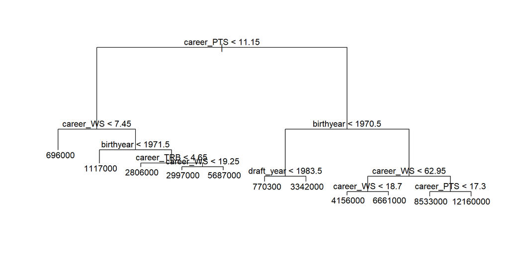

```r
plot(tree.nba_dataset)
text(tree.nba_dataset, pretty = 0)
```

Since the best tree is the unpruned tree, we predict the results with it, and obtain the RMSE (Root Mean Squared Error), as the root of the mean of the squared error between the model prediction and the real test value. I have chosen the RMSE instead of the MSE because it is a smaller and more interpretable quantity.

```r
yhat.tree <- predict(tree.nba_dataset, nba_dataset.test)
rmse_tree <- mean((yhat.tree - salary.test) ^ 2) %>% sqrt()
```

Finally we plot the predicted and real values using a scatterplot, to see how is the model performing. As we can see it performs very poorly (ideally there should be a linear relationship), and so I’ll try to improve the performance using bagging and random forests.

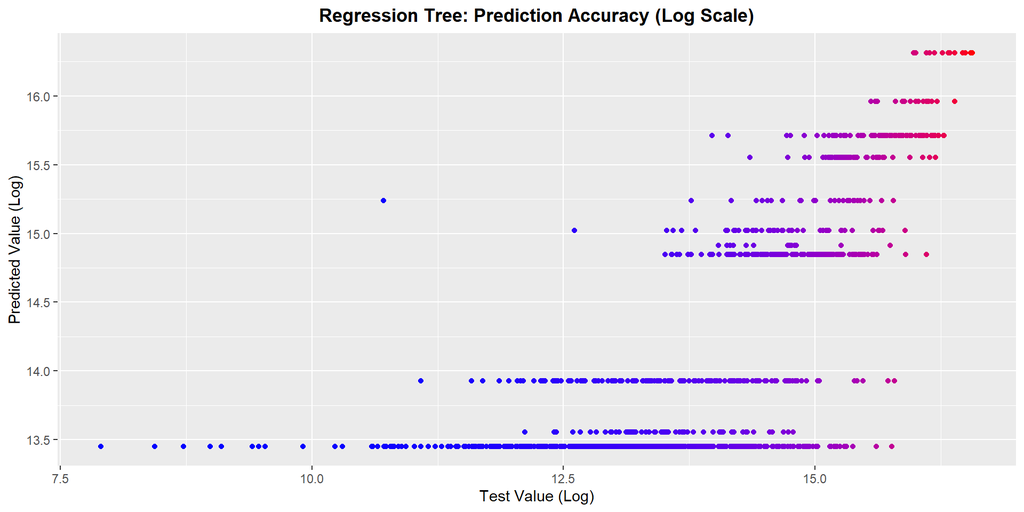

```r
plot_tree_data <- data.frame(test_value = salary.test, tree.pred = yhat.tree)
tree_plot <- ggplot(data = plot_tree_data, aes(x = log(test_value), y = log(tree.pred), color = test_value)) + geom_point() +
        scale_color_gradient(low = "blue", high = "red") +
        ggtitle("Regression Tree: Prediction Accuracy (Log Scale)") +
        theme(plot.title = element_text(hjust = 0.5, face = "bold"),
              axis.title = element_text(hjust = 0.5),
              legend.position = "none",
              legend.title = element_blank()) +
        xlab("Test Value (Log)") + ylab("Predicted Value (Log)")
tree_plot
```

### **Bagging**

In order to use the bagging algorithm I load the *randomForest* package, create training and testing partitions and train the model. Then I create a variable with the predicted values and another one to store the RMSE.

```r
library(randomForest)
set.seed(1)
bag.nba_dataset <- randomForest(carreer_avg_salary ~., data = nba_dataset, subset = train, mtry = ncol(nba_dataset) - 1, keep.forest = T)
yhat.bag <- predict(bag.nba_dataset, newdata = nba_dataset[-train, ])
rmse_bagging <- mean((yhat.bag - nba_dataset.test$carreer_avg_salary) ^ 2) %>% sqrt()
```

Finally I plot the same scatterplot (real vs predicted values), on a logged version of both (since it is more interpretable). As we can see the accuracy of the model is much more higher than in the single tree, and it already looks very robust. There is a clear linear relationship between the predicted and the real values, and this indicated that for every point the model is predicting values very close to the real test number.

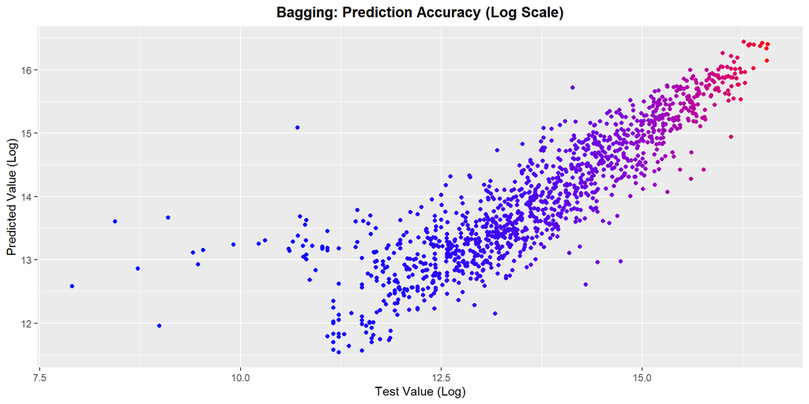

```r
plot_bag_data <- data.frame(test_value = salary.test, bag.pred = yhat.bag)
bag_plot <- ggplot(data = plot_bag_data, aes(x = log(test_value), y = log(bag.pred), color = test_value)) + geom_point() +
        scale_color_gradient(low = "blue", high = "red") +
        ggtitle("Bagging: Prediction Accuracy (Log Scale)") +
        theme(plot.title = element_text(hjust = 0.5, face = "bold"),
              axis.title = element_text(hjust = 0.5),
              legend.position = "none",
              legend.title = element_blank()) +
        xlab("Test Value (Log)") + ylab("Predicted Value (Log)")
bag_plot
```

### **Random Forest**

I use the same methodology than in the bagging implementation. This model looks even more robust than the previous due to the stronger linear relationship between predicted and the real values.

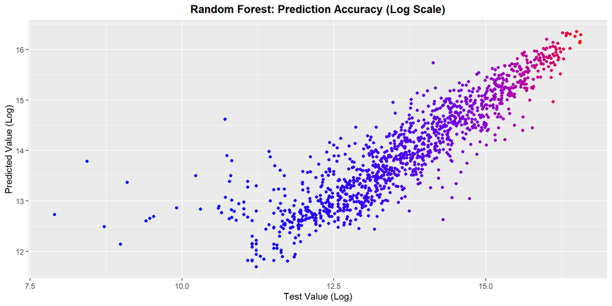

```r
set.seed(1)
rf.nba_dataset <- randomForest(carreer_avg_salary ~., data = nba_dataset,
                               subset = train, mtry = (ncol(nba_dataset) - 1) / 3,
                               keep.forest = T)
yhat.rf <- predict(rf.nba_dataset, newdata = nba_dataset[-train, ])
rmse_randomforest <- mean((yhat.rf - nba_dataset.test$carreer_avg_salary) ^ 2) %>% sqrt()
plot_rf_data <- data.frame(test_value = salary.test, rf.pred = yhat.rf)
rf_plot <- ggplot(data = plot_rf_data, aes(x = log(test_value), y = log(rf.pred), color = test_value)) + geom_point() +
        scale_color_gradient(low = "blue", high = "red") +
        ggtitle("Random Forest: Prediction Accuracy (Log Scale)") +
        theme(plot.title = element_text(hjust = 0.5, face = "bold"),
              axis.title = element_text(hjust = 0.5),
              legend.position = "none",
              legend.title = element_blank()) +
        xlab("Test Value (Log)") + ylab("Predicted Value (Log)")
rf_plot
```

## **Model Comparison and conclusions**

Finally I plot the previous charts as well as the table comparing the RMSE of each model, showing that the best model in performance is the Random Forest.

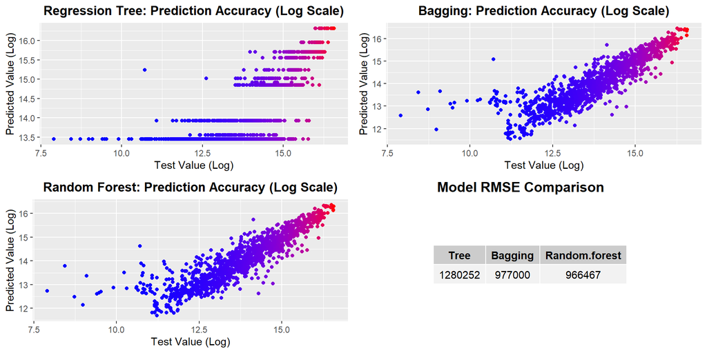

```r
rmse_comparison <- data.frame(Tree = round(rmse_tree),
                              Bagging = round(rmse_bagging),
                              "Random forest" = round(rmse_randomforest))
library(ggpubr)
rmse_comparison_table <- ggtexttable(rmse_comparison, rows = NULL)
final_chart <- ggarrange(tree_plot, bag_plot, rf_plot, rmse_comparison_table, labels = c("", "", "", "Model RMSE Comparison"))
final_chart
```

## **THANKS FOR YOUR ATTENTION**

[figure not shown]